# newsgroups_topic_modeling

## Topic Modelling

Topic Modeling is a process to automatically identify topics from large collections of text, for discovery of hidden patterns exhibited by a text corpus. It is used for finding groups of words (eg: topic) from a collection of documents that best represents the information in the collection. It has application in the following:

- Discovering hidden topical patterns that are present across the collection
- Annotating documents according to these topics
- Using these annotations to organize, search and summarize texts

Topic modeling can be implemented using cluster analysis such as K-means, LDA (Latent Dirichlet Allocation), as well as other techniques. In this session we look at cluster analysis and topic models. So what's the difference between these two methods?

In general, if a document is assigned to only a single topic, this is document clustering. However, if each document can have more than one topic, this task relates to the decomposition methods, such as LDA.

- Both are unsupervised tasks that attempts to organize/group documents
- Text clustering looks for similarity among documents to form similar document clusters. The similarity measures could be based on TF-IDF weighting.
- Topic models don't look at document similarity, but instead, treats a document as a mixture of topics in which a topic is a probability distribution of words, such that each document is assigned a probability of belonging to a latent theme or “topic.”
- Another advantage between topic models and conventional cluster analysis, is they use more sophisticated iterative Bayesian techniques to determine the probability that each document is associated with a given topic. So while the documents are initially given a random probability of being assigned to topics, these probabilities become increasingly accurate as more data are processed.

### Imports

```python
import warnings
warnings.filterwarnings('ignore')

import numpy as np
import pandas as pd

import string
import re

from pprint import pprint


from nltk.tokenize import word_tokenize
from nltk.corpus import stopwords
from nltk.stem.wordnet import WordNetLemmatizer
from nltk import FreqDist


import gensim
from gensim import corpora, models
from gensim.models import CoherenceModel

import pyLDAvis
import matplotlib.pyplot as plt

from sklearn.feature_extraction.text import TfidfVectorizer
from sklearn.cluster import KMeans
from sklearn.metrics import adjusted_rand_score
from sklearn.cluster import KMeans
from sklearn.metrics import silhouette_score
```

```python
#pip install pyLDAvis
#pip install --upgrade gensim
#pip install python-Levenshtein
```

### Read and inspect the data

```python
# read
df = pd.read_csv('./data/news_group_docs.csv', encoding="ISO-8859-1", engine='python')

df.head(3)
```

|  | content |
| --- | --- |
| 0 | From: jlevine@rd.hydro.on.ca (Jody Levine)\nSu... |
| 1 | From: gharriso@hpcc01.corp.hp.com (Graeme Harr... |
| 2 | From: charlie@elektro.cmhnet.org (Charlie Smit... |

### General statistics

```python
wordlen = df['content'].str.split().map(lambda x: len(x))
wordlen.describe()
```

```
count    1794.00000
mean      267.69398
std       300.10841
min        19.00000
25%       113.00000
50%       183.00000
75%       311.00000
max      5577.00000
Name: content, dtype: float64
```

```python
txtlen = df['content'].str.len()
txtlen.describe()
```

```
count     1794.000000
mean      1679.363434
std       1804.198807
min        171.000000
25%        778.000000
50%       1201.000000
75%       1935.750000
max      36272.000000
Name: content, dtype: float64
```

- 1794 observations
- average word length of 267 words with max of 5577 resulting in a skewed distribution
- average text length of 1679 characters and max of 36272

### Peek at the data to get an intuition about topics

```python
sample = df.content.sample(5)
for s in sample:
    print(s)
```

```
From: tcsteven@iaserv.b1.ingr.com (Todd Stevens)
Subject: Rebuilding the Temple (was Re: Anybody out there?)
Organization: ingr
Lines: 14

Chuck Petch writes:

>Now it appears that nothing stands in the way of rebuilding and resuming
>sacrifices, as the Scriptures indicate will happen in the last days.
>Although the Israeli government will give the permission to start, I think
>it is the hand of God holding the project until He is ready to let it
>happen. Brothers and sisters, the time is at hand. Our redemption is
>drawing near. Look up!

How is a scriptural Levitical priesthood resumed?  Are there any Jews who
can legitimately prove their Levite bloodline?

Todd Stevens
tcsteven@iaserv.b1.ingr.com

From: alird@Msu.oscs.montana.edu
Subject: Re: cubs & expos roster questions
Article-I.D.: Msu.0096B0F0.C5DE05A0
Reply-To: alird@Msu.oscs.montana.edu
Organization: Montana State University
Lines: 13

In article <1993Apr15.003015.1@vmsb.is.csupomona.edu>, cvadrnlh@vmsb.is.csupomona.edu writes:
>Today (4/14) Cubs activated P Mike Harkey from DL, whom did they move to make
>room for Harkey?
>Also, are Delino Deshields & John Wetteland of the Expos on the DL?
>Thanks for anyone who can give me more info!
>/===
>Ken
>Cal Poly, Pomona
>

Wetteland is on the DL effective March 26 or something like that.

rick
```

[output cut: 88 more lines]

```
justify jabbering.

But I'll buy the idea that someone could talk in a language never learned.

Trouble is, while such stories abound, any and all attempts at
verification (and we are to test the spirit...) either show that
the witness had no real idea of the circumstances, or that outright
fabrication was involved.  The Brother Puka story in a previous post
seems like a "friend of a friend" thing.  And linguistically, a two
syllable word hardly qualifies as language, inflection or no.

Much as many faith healers have trouble proving their "victories" (since
most ailments "cured" are just plain unprovable) and modern day
ressurrections have never been validated, so is it true that no
modern day xenoglossolalia has been proved by clergy OR lay.
```

Discussions (topics) revolve around religion, sports (baseball), riding bike/motorcycle,

### Text preprocessing

Removing high frequency words (eg: stop words), punctuation, stemming/lemmatization, etc

```python
stop_words = stopwords.words('english')
stop_words.extend(['from', 'subject', 'organization', 'article', 're', '.edu', 'writes', 'also', 'say',
                   'may', 'u', 'would', 'get', 'even', 'could', 'still'])

others = ['--', '``', '==============|', '...', '-', '.', ':', '.', "''"]

useless_words = stop_words + list(string.punctuation) + others

lemma = WordNetLemmatizer()


# Cleaning the text
def clean_message(doc):

    doc = doc.lower()                                                         # lower-case
    doc = re.sub(r"http\S+", '', doc)                                         # remove urls
    doc = re.sub(r"nntp\S+", '', doc)                                         # remove urls

    doc = re.sub(r'\S*@\S*\s?', '', doc)                                      # remove email
    doc = re.sub(r'\d+', '', doc)                                             # remove numbers
    doc = re.sub('/\r?\n|\r/', '', doc)                                      # remove new line
    doc = re.sub("\'", '', doc)                                              # Remove single quotes
    doc = ' '.join(lemma.lemmatize(word) for word in doc.split())              # lemmatization
    doc = ' '.join([w for w in word_tokenize(doc) if w not in useless_words])  # stop, punctuation removal

    return doc.split()


def getCleanText(doc):
    clean_lines = []
    for line in doc:
        line = line.strip()   # remove leading/trailing spaces
        cleaned = clean_message(line)
        cleaned = ' '.join(cleaned)
        clean_lines.append(cleaned)

    return clean_lines
```

```python
docs = df['content'].to_list()
clean_docs = getCleanText(docs) # list of clean docs

# first 5 docs
clean_docs[:5]
```

```
['jody levine drinking riding eww gross ontario hydro research division lines mike muise hr/drink first drinks hours/drink next drinks hours/drink rest case go first four fifth one usually make throw last two needle dont drink much anymore last time happened wa second year undergrad wa silly breath …
 'graeme harrison used bikes east vs. west coast hp corporate note server lines hpcc rec.motorcycles grover cleveland apr shop bike sacramento bay area price always much higher elsewhere state gc affirmative check sacramento bee fresno bee modesto stockton bakersfield newspaper price motos classifie…
 'charlie smith looking maintenance manual honda cb suspect lines duncan d. sterling anyone think touring cb pushing envelope try twin local honda dealer honda dream commonly referred serious touring bike first came maybe something water around whats problem back rode puch paris barcelona back wa tw…
 'michael manning bike contact icom simulation lines michael manning must blockhead .the gargoyle thing work michael menard p.s showin highland house well compare sunglasses let see weather saturday sunday suck today time good youre welcome give one try gargoyles want mine em think bridge nose hold …
 'andrew infante definition two distribution usa duke university durham n.c. lines north.acpub.duke.edu following logic describe two transition period two coming rest high low side otherwise sound pretty good richard pierson e vnet perhaps referring wife child sitting sidecar next one-up moto anyone…
```

### Inspect our corpus

plot top common words

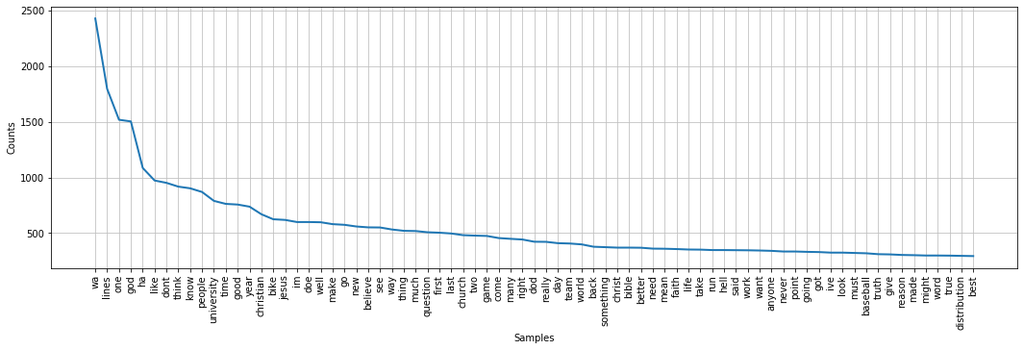

```python
texts = "".join(clean_docs)
word_tokens = word_tokenize(texts)
#fdist.most_common(50)

plt.figure(figsize=(18, 5))
fdist = FreqDist(word_tokens)
fdist.plot(75);
```

Inspection of top words suggests the corpus contains topics relating to

- religion (eg: god, christian, jesus, church, faith)
- sports (eg: game, team, baseball)

## K-Means Model

Clustering is a common data analysis technique used to get an intuition about the structure of the data. The goal is to find homogeneous subgroups within the data such that data points in each cluster are as similar as possible according to a similarity measure such as euclidean-based distance or correlation-based distance.

Unlike supervised learning, clustering is an unsupervised learning method since we don’t have the ground truth to compare the output of the algorithm to the true labels to evaluate its performance. Since kmeans requires k as an input and doesn’t learn it from data, there is no right answer in terms of the number of clusters needed for a problem and often domain knowledge and intuition may help. However there are 2 metrics that may provide some intuition about k:

- **Elbow method**: provides an idea on a good k number of clusters based on the sum of squared distance (SSE) between data points and their assigned clusters’ centroids
- **Silhouette analysis**: used to determine the degree of separation between cluster. The coefficient values range from (-1, 1) where 0 indicates the sample is very close to the neighboring cluster, 1 indicates the sample is far away from the neighboring cluster and -1 indicates the sample is assigned to the wrong clusters. Hence, we want coefficients to be as big as possible and close to 1 to have a good clusters.

### Vectorization

```python
#vectorization of features
vectorizer = TfidfVectorizer()
X = vectorizer.fit_transform(clean_docs)

X.shape
```

```
(1794, 21400)
```

### Determining number of clusters

Use Elbow method to determine number of k (clusters)

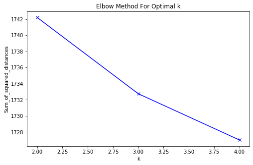

```python
def elbow_method(X, num_k):
    Sum_of_squared_distances = []
    for k in range(2, num_k):
        km = KMeans(n_clusters=k)
        km = km.fit(X)
        Sum_of_squared_distances.append(km.inertia_)

    # plot the cost against K values
    plt.figure(figsize=(8, 5))

    plt.plot(range(2, num_k), Sum_of_squared_distances, 'bx-')
    plt.xlabel('k')
    plt.ylabel('Sum_of_squared_distances')
    plt.title('Elbow Method For Optimal k')
    plt.show()

elbow_method(X, 5)
```

elbow method suggests k = 3

Use the silhouette score to determine cluster size

```python
def get_silhouette_score(X, k):
    for n_clusters in range(2, k):
        clusterer = KMeans(n_clusters=n_clusters, random_state=42)
        y = clusterer.fit_predict(X)

        message = "For n_clusters = {} The average silhouette_score is: {}"
        print(message.format(n_clusters, silhouette_score(X, y)))

get_silhouette_score(X, 5)
```

```
For n_clusters = 2 The average silhouette_score is: 0.006260807743410956
For n_clusters = 3 The average silhouette_score is: 0.0081142702448767
For n_clusters = 4 The average silhouette_score is: 0.00803360954395064
```

low silhouette score do not suggest that the topcis are very distinquishable

### train K-Means model using k = 3

```python
true_k = 3
kmeans = KMeans(n_clusters=true_k, init='k-means++', max_iter=100, n_init=1, random_state=42)
kmeans.fit(X)


print("Top terms per cluster:")
order_centroids = kmeans.cluster_centers_.argsort()[:, ::-1]
terms = vectorizer.get_feature_names()

for i in range(true_k):
    print("Cluster %d:" % i),
    for ind in order_centroids[i, :15]:
        print(' %s' % terms[ind]),
```

```
Top terms per cluster:
Cluster 0:
 bike
 dod
 wa
 lines
 one
 like
 motorcycle
 university
 ride
 dog
 helmet
 bmw
 riding
 im
 new
Cluster 1:
 game
 team
 year
 baseball
 wa
 player
 run
 win
 lines
 ha
 university
 last
 jewish
 edu
 fan
Cluster 2:
 god
 christian
 jesus
 wa
 people
 church
 one
 bible
 christ
 believe
 faith
 truth
 hell
 know
 think
```

Cluster 0: relates to riding, motorcycle  
Cluster 1: relates to sports  
Cluster 2: relates to religon

### Inspect Clusters

```python
# assign the data labels back to the dataframe
df['clusters'] = kmeans.labels_

df.sample(10, random_state=42)
```

|  | content | clusters |
| --- | --- | --- |
| 1234 | From: REXLEX@fnal.fnal.gov\nSubject: Re: RE: D... | 2 |
| 220 | From: leavitt@cs.umd.edu (Mr. Bill)\nSubject: ... | 0 |
| 1516 | From: kwyatt@ccscola.columbiasc.ncr.com (Kersh... | 2 |
| 438 | From: tcora@pica.army.mil (Tom Coradeschi)\nSu... | 0 |
| 1268 | From: dwatson@cser.encore.com (Drew Watson)\nS... | 2 |
| 832 | From: dholle15@ursa.calvin.edu (David Hollebee... | 0 |
| 692 | From: niepornt@phoenix.Princeton.EDU (David Ma... | 1 |
| 1307 | From: atterlep@vela.acs.oakland.edu (Cardinal ... | 2 |
| 1100 | From: Eastgate@world.std.com (Mark Bernstein)\... | 1 |
| 1526 | From: mwhaefne@infonode.ingr.com (Mark W. Haef... | 2 |

```python
# cluster 2 (religion)
print(df.content[1234])

# cluster 0 (riding, motorcycle)
print(df.content[220])

# cluster 1 (sports)
print(df.content[832])
```

```
From: REXLEX@fnal.fnal.gov
Subject: Re: RE: Does God love you?
Organization: FNAL/AD/Net
Lines: 70

In article <Apr.13.00.08.10.1993.28382@athos.rutgers.edu> jayne@mmalt.guild.org
(Jayne Kulikauskas) writes:

>I am uncomfortable with the tract in general because there seems to be
>an innappropriate emphasis on Hell.  God deserves our love and worship
>because of who He is.  I do not like the idea of frightening people into
>accepting Christ.

And yet, Jayne,  as we read the Gospels and in particular the topics that Jesus
himself spoke on, Hell figures in a large % of the time -certainly more than
heaven itself.  Paul, as we learn in I Thess, taught new believers and new
churches eschatology and did not hesitate to teach hell and damnation.  Rev,
chapter 20:11-15 is very specific and cannot be allegorized.  I think the word
"throne" is used 45 times in Rev and that the unbelieving come to receive the
assignment of the severity of judgement, for in John 3 we read that they are
already judged.  Rom 3 speaks that every mouth will be shut.  There is no
recourse, excuse or defense.
>
>I see evangelism as combining a way of living that shows God's love with
>putting into words and explaining that love.  Preaching the Gospel
>without living the Gospel is no better than being a noisy gong or a
>clanging cymbal.

Yes I agree with you.  Life is often like a pendulum where it swings to
extremes before stopping at "moderation."  I think we have seen the extreme of
the "hell fire & brimstone" preacher, but also we have seen the other extreme
where hell not talked about at all for fear of offending someones
sensibilities.

I forget who founded the Word of Life Ministries, but I remember him telling a
story.  He was in a small town hardware store and some how a man got to the
point of telling him that he didn't believe in Satan or hell.  He believed
everybody was going to heaven.  It was at this point that the man was asked to
pray to God that He would send his children to hell!  Of course the man
wouldn't do it.  But the point was made.  Many people say they don't believe in
```

[output cut: 82 more lines]

```
+ "Hmmm, I thought bore and stroke *was* the technique!" Michael Bain, #757 +

From: dholle15@ursa.calvin.edu (David Hollebeek)
Subject: Phillies Mailing List?
Nntp-Posting-Host: ursa
Organization: Calvin College
Lines: 7

Anyone know of a phillies mailing list out there? .... they don't get much
coverage up here in Grand Rapids, MI *sob*

--
-------------------------------------------------------------------------------
"Elaborate .signature files are for people who aren't as busy as I am" -DH 1992
---------------------David-Hollebeek---dholle15@ursa.calvin.edu----------------
```

### predict new documents

```python
new_docs = ["My love of sports started when I was a kid when I played base-ball in a league.",
            "People of faith have hope in a higher power. Believing in God gives sense to the world.",
            "There is no better sense of freedom than getting on my Harley motor cycle on a long road trip."]

pred = kmeans.predict(vectorizer.transform(new_docs))
print(pred)
```

```
[1 2 0]
```

prediction of new documents seems correct.

## Latent Dirichlet Allocation (LDA)

LDA is a topic model used to classify text in a document to a particular topic. It builds a topic per document model and words per topic model, modeled as Dirichlet distributions. LDA assumes documents are produced from a mixt of topics found within the entire corpus. Those topics then generate words based on their probability distribution. Note: the topic structure is hidden (or latent) as we only observe the documents/words, not the topics themselves. Therefore this method is used to *infer* topic structure, given the known words and documents.

The basic approach starts with preparing a document-term matrix. For each document, count how many times a particular term occurs. Since not all terms are equally important, TF-IDF weighting can be used rather than raw counts. The next step is to decompose this matrix into document-topic and term-topic matrices. Next, the analyst will look at the main terms of each topic in order to label or identify the names of these topics. Since number of topics is far fewer than the vocabulary, topic modelling can also be used as a dimensionality reduction technique.

The basic pipeline/process involves:

- preparing documents
- cleaning/preprocessing
- preparing document term matrix
- running LDA model
- results evaluation
  - human judgment/Observation-based (eg. observing the top ‘N’ words in a topic)
  - quantitative metrics such as perplexity (held out likelihood) and coherence calculations
  - mixture of human judgement and quantitative

## LDA topic modeling with Gensim

In the following, we will use Gensim (a free open-source Python library) for LDA topic modeling. The core concepts of gensim are:

1. **Document**: anything from a short tweet, a paragraph (i.e., journal article abstract), a news article, or a book
2. **Corpus**: a collection of documents. Corpora serve two roles in Gensim:
   - *Input for training a Model*: During training, a model uses this training corpus to look for common themes/topics.
   - *Documents to organize*: After training, a topic model can be used to extract topics from new documents (eg: unseen in the training corpus).

After collecting our corpus, there are typically a number of preprocessing steps such as removing high frequency words (eg: stop words), stemming/lemmatization, etc..

1. **Vector**: a mathematically convenient representation of a document.
2. **Model**: an algorithm for transforming vectors from one representation to another.

### Creating a corpus

- Preprocessing text

```python
clean_docs = df['content'].map( clean_message)

print ('orignal before cleaning\n')
print(df['content'][0])

print('after cleaning\n')
print(clean_docs[0])
```

```
orignal before cleaning

From: jlevine@rd.hydro.on.ca (Jody Levine)
Subject: Re: Drinking and Riding (eww, gross)
Organization: Ontario Hydro - Research Division
Lines: 16

In article <MJMUISE.38.733926270@1302.watstar.uwaterloo.ca> MJMUISE@1302.watstar.uwaterloo.ca (Mike Muise) writes:
>
>1 hr/drink for the first 4 drinks.
>1.5 hours/drink for the next 6 drinks.
>2 hours/drink for the rest.

In my case it goes down after the first four, because the fifth one usually
makes me throw up the last two.

Needless to say, I don't drink very much anymore, as the last time that
happened was in the second year of my undergrad. I was a silly .edu breath,
and pretty bad breath at that.

I've        bike                      like       | Jody Levine  DoD #275 kV
     got a       you can        if you      -PF  | Jody.P.Levine@hydro.on.ca
                         ride it                 | Toronto, Ontario, Canada

after cleaning

['jody', 'levine', 'drinking', 'riding', 'eww', 'gross', 'ontario', 'hydro', 'research', 'division', 'lines', 'mike', 'muise', 'hr/drink', 'first', 'drinks', 'hours/drink', 'next', 'drinks', 'hours/drink', 'rest', 'case', 'go', 'first', 'four', 'fifth', 'one', 'usually', 'make', 'throw', 'last', 'tw…
```

```python
# first 3 docs from preprocess docments
print(clean_docs[:3])
```

```
0    [jody, levine, drinking, riding, eww, gross, o...
1    [graeme, harrison, used, bikes, east, vs., wes...
2    [charlie, smith, looking, maintenance, manual,...
Name: content, dtype: object
```

### Bag of Words

To infer the latent structure in our corpus we need a way to represent documents that we can manipulate mathematically. One approach to represent a document as a vector is the *bag-of-words* model. Here each document is represented by a vector containing the frequency counts of each word in the dictionary.

For example: assuming a dictionary containing the words ['coffee', 'milk', 'sugar', 'spoon'].

A document consisting of the string "coffee milk coffee" would be represented by the vector [2, 1, 0, 0]

```python
# create a dictionary from the corpus
dictionary = gensim.corpora.Dictionary(clean_docs)
print(dictionary)

# Term Document Frequency
# convert our entire corpus to a list of vectors:
bow_corpus = [dictionary.doc2bow(doc) for doc in clean_docs]

# View the first doc
print(bow_corpus[0])
```

```
Dictionary(23772 unique tokens: ['-pf', 'anymore', 'bad', 'bike', 'breath']...)
[(0, 1), (1, 1), (2, 1), (3, 1), (4, 2), (5, 1), (6, 1), (7, 1), (8, 1), (9, 1), (10, 1), (11, 1), (12, 2), (13, 1), (14, 1), (15, 2), (16, 1), (17, 1), (18, 1), (19, 1), (20, 1), (21, 2), (22, 1), (23, 1), (24, 1), (25, 2), (26, 1), (27, 2), (28, 2), (29, 1), (30, 1), (31, 1), (32, 1), (33, 1), (34…
```

Gensim creates a unique id for each word in the document. The produced corpus shown above is a mapping of (word_id, word_frequency).

- For example, (0, 1) above implies, word id 0 occurs once in the first document. Likewise, word id 1 occurs 1 and so on.

Next show the words in document 0 in human readable format

```python
doc = bow_corpus[0]
for i in range(len(doc)):
    #print (doc[i][0], dictionary[doc[i][0]], doc[i][1])
    print (f"Word {doc[i][0]} ({dictionary[doc[i][0]]}) appears {doc[i][1]} times")
```

```
Word 0 (-pf) appears 1 times
Word 1 (anymore) appears 1 times
Word 2 (bad) appears 1 times
Word 3 (bike) appears 1 times
Word 4 (breath) appears 2 times
Word 5 (canada) appears 1 times
Word 6 (case) appears 1 times
Word 7 (division) appears 1 times
Word 8 (dod) appears 1 times
Word 9 (dont) appears 1 times
Word 10 (drink) appears 1 times
Word 11 (drinking) appears 1 times
Word 12 (drinks) appears 2 times
Word 13 (eww) appears 1 times
Word 14 (fifth) appears 1 times
Word 15 (first) appears 2 times
Word 16 (four) appears 1 times
Word 17 (go) appears 1 times
Word 18 (got) appears 1 times
Word 19 (gross) appears 1 times
Word 20 (happened) appears 1 times
Word 21 (hours/drink) appears 2 times
Word 22 (hr/drink) appears 1 times
Word 23 (hydro) appears 1 times
Word 24 (ive) appears 1 times
Word 25 (jody) appears 2 times
Word 26 (kv) appears 1 times
Word 27 (last) appears 2 times
Word 28 (levine) appears 2 times
Word 29 (like) appears 1 times
Word 30 (lines) appears 1 times
Word 31 (make) appears 1 times
Word 32 (mike) appears 1 times
Word 33 (much) appears 1 times
Word 34 (muise) appears 1 times
Word 35 (needle) appears 1 times
Word 36 (next) appears 1 times
Word 37 (one) appears 1 times
Word 38 (ontario) appears 2 times
Word 39 (pretty) appears 1 times
Word 40 (research) appears 1 times
Word 41 (rest) appears 1 times
Word 42 (ride) appears 1 times
Word 43 (riding) appears 1 times
Word 44 (second) appears 1 times
Word 45 (silly) appears 1 times
Word 46 (throw) appears 1 times
Word 47 (time) appears 1 times
Word 48 (toronto) appears 1 times
Word 49 (two) appears 1 times
Word 50 (undergrad) appears 1 times
Word 51 (usually) appears 1 times
Word 52 (wa) appears 2 times
Word 53 (year) appears 1 times
```

The tfidf model again returns a list of tuples, where the first entry is the token ID and the second entry is the tf-idf weighting.

## Building the Topic Model

In addition to the corpus and dictionary, we need to provide the number of topics to build a topic model.

- alpha and eta are hyperparameters affecting sparsity of the topics. According to the Gensim docs, both defaults to 1.0/num_topics prior.
- chunksize: the number of documents to be used in each training chunk
- update_every: determines how often the model parameters should be updated
- passes: the total number of training passes

### Build a model using bag of words

```python
NUM_TOPICS = 3

# Build LDA model
lda_model = gensim.models.ldamodel.LdaModel(corpus=bow_corpus,
                                           id2word=dictionary,
                                           num_topics=NUM_TOPICS,
                                           random_state=42,
                                           update_every=1,
                                           chunksize=100,
                                           passes=10,
                                           alpha='auto',
                                           per_word_topics=True)
### View the topics in LDA model
topics = lda_model.print_topics()
for topic in topics:
    print(topic)
```

```
(0, '0.014*"god" + 0.011*"wa" + 0.008*"one" + 0.007*"people" + 0.007*"christian" + 0.006*"jesus" + 0.005*"lines" + 0.005*"ha" + 0.005*"church" + 0.005*"think"')
(1, '0.008*"lines" + 0.004*"wa" + 0.004*"bike" + 0.004*"like" + 0.004*"one" + 0.003*"dod" + 0.003*"university" + 0.003*"im" + 0.003*"know" + 0.003*"please"')
(2, '0.009*"wa" + 0.008*"lines" + 0.008*"year" + 0.006*"game" + 0.005*"team" + 0.005*"university" + 0.004*"ha" + 0.004*"last" + 0.004*"good" + 0.004*"baseball"')
```

Note: words like "wa", "lines", "iniversity" are repeated across topics and don't look to be topic specific words, so it may be worthwhile to remove these words

### Test with unseen document

```python
new_doc = 'My love of sports started when I was a kid when I played base-ball in a league.'
new_doc = clean_message(new_doc)
new_doc_bow = dictionary.doc2bow(new_doc)

print(new_doc_bow)
print(lda_model.get_document_topics(new_doc_bow))
```

```
[(52, 1), (368, 1), (703, 1), (718, 1), (957, 1), (1664, 1), (3060, 1)]
[(0, 0.041365087), (1, 0.010978373), (2, 0.9476566)]
```

The LDA out put shows that topic 2 has the highest probability assigned, followed by topic 0, then topic 1. This does appear to match the topic relating to baseball

### Model Perplexity and Coherence Score

Model perplexity and topic coherence provide a convenient measure to judge how good a given topic model is.

```python
def lda_scoring (model, corpus, text, dictionary):

    # Compute Perplexity
    print('\nPerplexity: ', model.log_perplexity(corpus))  # a measure of how good the model is. lower the better.

    # Compute Coherence Score
    coherence_model_lda = CoherenceModel(model=model,
                                         texts=text,
                                         dictionary=dictionary,
                                         coherence='c_v')

    coherence_lda = coherence_model_lda.get_coherence()
    print('\nCoherence Score: ', coherence_lda)
```

```python
lda_scoring(lda_model, bow_corpus, clean_docs, dictionary)
```

```
Perplexity:  -8.534324427303478

Coherence Score:  0.44254468733525004
```

### Visualize the topics

pyLDAvis is designed to help users interpret the topics in a topic model that has been fit to a corpus of text data. The package extracts information from a fitted LDA topic model to inform an interactive web-based visualization.

```python
import pyLDAvis
import pyLDAvis.gensim_models as gensimvis

pyLDAvis.enable_notebook()

# feed the LDA model into the pyLDAvis instance
lda_viz = gensimvis.prepare(lda_model, bow_corpus, dictionary, sort_topics=False)

pyLDAvis.display(lda_viz)
```

[interactive chart not shown]

## LDA using TF-IDF

Above we built a topic model using simple bag-of-words. Instead we can create a tf-idf model, which transforms vectors from the bag-of-words representation to a vector space where the frequency counts are weighted according to the relative rarity of each word in the corpus.

```python
tfidf = models.TfidfModel(bow_corpus)
corpus_tfidf = tfidf[bow_corpus]

for doc in corpus_tfidf[0]:
    pprint(doc)
```

```
(0, 0.13909927685273152)
(1, 0.11871011402385903)
(2, 0.07334219815889552)
(3, 0.05052723897251496)
(4, 0.28832809057131104)
(5, 0.09050769852650412)
(6, 0.06612075552303016)
(7, 0.08281968898727353)
(8, 0.048149926454335426)
(9, 0.03244191162128018)
(10, 0.11273446668843239)
(11, 0.10781945235191209)
(12, 0.3552191764163082)
(13, 0.20812828790287455)
(14, 0.12942355456773916)
(15, 0.09406690243535426)
(16, 0.10565373393023293)
(17, 0.04246412323730723)
(18, 0.054857211506021)
(19, 0.15835443253044282)
(20, 0.08605348912399273)
(21, 0.3552191764163082)
(22, 0.16961797654745195)
(23, 0.14151639352961662)
(24, 0.05496899965529851)
(25, 0.23112384096128752)
(26, 0.13909927685273152)
(27, 0.09440464593877056)
(28, 0.2498177792158884)
(29, 0.028938621326546902)
(30, 0.00010860400498859799)
(31, 0.04107138458044703)
(32, 0.0720696405080172)
(33, 0.043630880244218684)
(34, 0.1776095882081541)
(35, 0.13481707615835503)
(36, 0.06949747607453766)
(37, 0.023424034318520442)
(38, 0.2498177792158884)
(39, 0.07186310187920543)
(40, 0.08471446762823141)
(41, 0.08471446762823141)
(42, 0.07165808753460529)
(43, 0.07884444520183811)
(44, 0.06749285256085379)
(45, 0.14416404528565552)
(46, 0.11099769383489617)
(47, 0.03738745533210543)
(48, 0.09581508262916483)
(49, 0.04669875659539028)
(50, 0.20812828790287455)
(51, 0.08571263432480787)
(52, 0.04091527466862171)
(53, 0.044385799461638266)
```

```python
lda_model_tfidf = gensim.models.ldamodel.LdaModel(corpus=corpus_tfidf,
                                           id2word=dictionary,
                                           num_topics=NUM_TOPICS,
                                           random_state=42,
                                           update_every=1,
                                           chunksize=100,
                                           passes=10,
                                           alpha='auto',
                                           per_word_topics=True)

### View the topics in LDA model
topics = lda_model.print_topics()
for topic in topics:
    print(topic)
```

```
(0, '0.014*"god" + 0.011*"wa" + 0.008*"one" + 0.007*"people" + 0.007*"christian" + 0.006*"jesus" + 0.005*"lines" + 0.005*"ha" + 0.005*"church" + 0.005*"think"')
(1, '0.008*"lines" + 0.004*"wa" + 0.004*"bike" + 0.004*"like" + 0.004*"one" + 0.003*"dod" + 0.003*"university" + 0.003*"im" + 0.003*"know" + 0.003*"please"')
(2, '0.009*"wa" + 0.008*"lines" + 0.008*"year" + 0.006*"game" + 0.005*"team" + 0.005*"university" + 0.004*"ha" + 0.004*"last" + 0.004*"good" + 0.004*"baseball"')
```

### References:

1. Devopedia. 2020. "Topic Modelling." Version 7, January 14. Accessed 2021-03-28. https://devopedia.org/topic-modelling
2. https://www.analyticsvidhya.com/blog/2016/08/beginners-guide-to-topic-modeling-in-python/
3. https://towardsdatascience.com/k-means-clustering-algorithm-applications-evaluation-methods-and-drawbacks-aa03e644b48a
4. Gensim: https://radimrehurek.com/gensim/auto_examples/core/run_core_concepts.html#sphx-glr-auto-examples-core-run-core-concepts-py
5. LDA requires specification of the number of topics. There is not hard rule for this and often requires trying different models and comparing. See following for some some general advise: https://www.machinelearningplus.com/nlp/topic-modeling-gensim-python/#17howtofindtheoptimalnumberoftopicsforlda